# MAE 5905: Introdução à Ciência de Dados

## Prova 1. Primeiro Semestre de 2023. Entregar 19/05/2023.

Aluno: Leonardo Makoto Kawahara - 7180679

```r
set.seed(1)
library(tidyverse)
library(MASS)
library(ISLR)
library(caret)
library(glmnet)
library(ggplot2)
```

# Exercício 1

## Item 1a

Considere o caso de duas populações exponenciais, uma com média 1 e outra com média 0,5. Supondo $\pi_1$ = $\pi_2$, encontre o classificador de Bayes. Quais são as probabilidades de classificação incorreta? Construa um gráfico, mostrando a fronteira de decisão e as regiões de classificação em cada população. Generalize para o caso das médias serem $\alpha > 0$ e $\beta > 0$, respectivamente.

### Resposta:

Sejam $X_1$ e $X_2$ variáveis aleatórias com média 1 e média 0,5, respectivamente. Temos que
$$\begin{equation}
f(x_1;\lambda_1)=
\begin{cases}
\lambda_1 e^{-\lambda_1 x}, & \text{se}\ x_1 \geq 0 \\
0, & \text{caso contrário}
\end{cases}
\\
f(x_2;\lambda_2)=
\begin{cases}
\lambda_2 e^{-\lambda_2 x}, & \text{se}\ x_2 \geq 0 \\
0, & \text{caso contrário}
\end{cases}
\end{equation}$$

A probabilidade de classifição incorreta é dadao por:
$$\begin{equation}
P(C_k | C_j, R) = \int_{\chi_k} f_j(x) dx
\end{equation}$$

Como temos duas classes, para elementos com valor das variáveis preditoras igual a x devem ser classicada em $C_1$ se

$$\begin{equation}
\frac{f_1(x)}{f_2(x)} \geq \frac{\pi_2}{\pi_1} = \frac{0,5}{0,5} = 1
\end{equation}$$
e em $C_2$, caso contrário.

Logo, temos que,
$$\begin{equation}
\chi_2= [0; log2] \\
\chi_1 = [log2;\infty] \\
\end{equation}$$
Pela formula de probabilidade de classificação incorreta
$$\begin{equation}
P(C_1 | C_2; R) = \int^\infty_{log2}2e^{-2x}dx = 0.25\\
P(C_2 | C_1; R) = \int^{log2}_{0}e^{-x}dx = -e^{-log2} - (-e^0 ) =
\frac{1}{2} \\
\end{equation}$$

Criando o gráfico de fronteiras

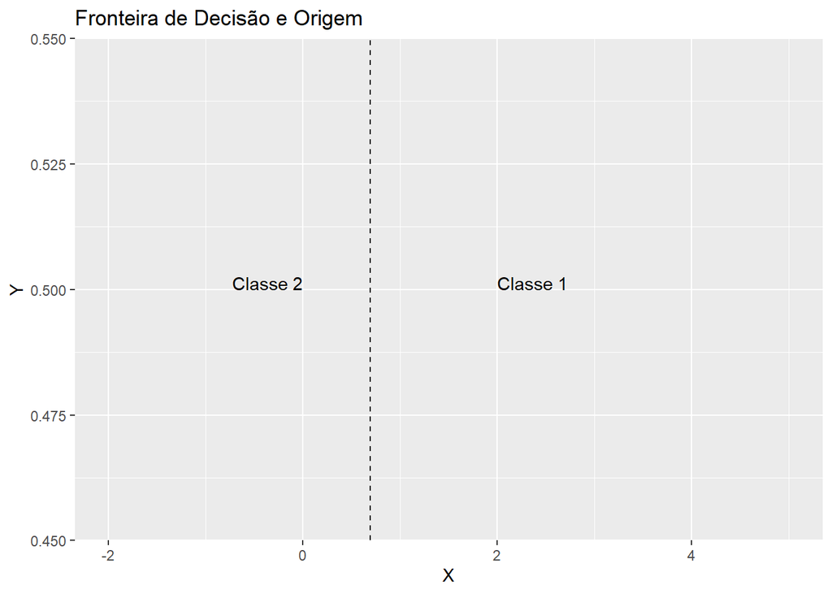

```r
# Gerando os dados de exemplo

# Criando o gráfico
ggplot() +

  geom_vline(xintercept = log(2), linetype = "dashed") +
  geom_text(aes(x = 2, y = 0.5, label = "Classe 1"), hjust = 0, vjust = 0) +
  geom_text(aes(x = 0, y = 0.5, label = "Classe 2"), hjust = 1, vjust = 0) +
  labs(x = "X", y = "Y", title = "Fronteira de Decisão e Origem") +
  xlim(-2, 5)
```

Generalizando, temos que
$$\begin{equation}
f(x_1;\lambda_1 = \frac{1}{\alpha})=
\begin{cases}
\frac{1}{\alpha} e^{-\frac{1}{\alpha} x}, & \text{se}\ x_1 \geq 0 \\
0, & \text{caso contrário}
\end{cases}
\\
f(x_2;\lambda_2 = \frac{1}{\beta})=
\begin{cases}
\frac{1}{\beta}e^{-\frac{1}{\beta} x}, & \text{se}\ x_2 \geq 0 \\
0, & \text{caso contrário}
\end{cases}
\end{equation}$$

Como temos duas classes, para elementos com valor das variáveis preditoras igual a x devem ser classicada em $C_1$ se

$$\begin{equation}
\frac{f_1(x)}{f_2(x)} \geq \frac{\pi_2}{\pi_1} = \frac{0,5}{0,5} = 1
\end{equation}$$

Isto é,
$$\begin{equation}
\frac{\frac{1}{\alpha} e^{-\frac{1}{\alpha}
x}}{\frac{1}{\beta}e^{-\frac{1}{\beta} x}} \geq 1 \longrightarrow
e^{x(\frac{\alpha - \beta}{\alpha\beta})} \geq \frac{\alpha}{\beta}
\longrightarrow
x \geq log(\frac{\alpha}{\beta})\frac{\alpha \beta}{\alpha-\beta}
\end{equation}$$

Então, temos que
$$\begin{equation}
\chi_1 = [log(\frac{\alpha}{\beta})\frac{\alpha \beta}{\alpha-\beta};
\infty] \\
\chi_2 = [0;log(\frac{\alpha}{\beta})\frac{\alpha \beta}{\alpha-\beta}]
\\
\end{equation}$$

Pela formula de probabilidade de classificação incorreta
$$\begin{equation}
P(C_1 | C_2; R) = \int^\infty_{log(\frac{\alpha}{\beta})\frac{\alpha
\beta}{\alpha-\beta}}\frac{1}{\beta}e^{-\frac{1}{\beta} x}dx \\
P(C_2 | C_1; R) = \int^{log(\frac{\alpha}{\beta})\frac{\alpha
\beta}{\alpha-\beta}}_{0}\frac{1}{\alpha} e^{-\frac{1}{\alpha} x}dx \\
\end{equation}$$

## Item 1b

Simule 200 observações de cada distribuição exponencial da parte (a). Usando os dados para estimar os parâmetros, supostos agora desconhecidos, obtenha o classificador de Bayes, a fronteira de decisão e as probabilidades de classificação incorreta com a regra obtida no exercício anterior. Compare os resultados com aqueles obtidos no item (a).

### Resposta:

Simulando cada distribuição exponecial

```r
lamda_1 <- 1
lambda_2 <- 2
n <- 200

amostra_1 <- rexp(n, rate = 1/lamda_1)
amostra_2 <- rexp(n, rate = 1/lambda_2)
```

Vamos assumir que os parâmetros são desconhecidos Nesse contexto, vamos assumir que $X_j|Y = k \sim exp(\lambda_i)$. Temos que estmiar a média e variância para cada amostra:

```r
media_1 <-  mean(amostra_1)

media_2 <-  mean(amostra_2)
```

A fronteira de classificação, portanto, é 1.3526

# Exercício 2

Considere os dados do arquivo `disco` e a variável resposta `y` = 1 se o disco estiver deslocado e `y` = 0, caso contrário. Use a função discriminante linear de Fisher para obter um classificador. Tome o conjunto de treinamento aquele contendo as primeiras 80 observações e o conjunto de teste contendo as demais 24 observações. Obtenha um classificador tendo como variável preditora a distância aberta e outro tendo como preditores as duas distâncias. Use a função `lda()` do pacote `MASS`. Interprete os resultados e escolha o melhor classificador usando a acurácia como base. Obtenha a sensibilidade e especificidade de cada classificador.

### Resposta:

Extraindo o arquivo

```r
disco <- readxl::read_excel("disco.xls")
head(disco)
```

```
## # A tibble: 6 x 3
##   deslocamento distanciaA distanciaF
##          <dbl>      <dbl>      <dbl>
## 1            0        2.2        1.4
## 2            0        2.4        1.2
## 3            0        2.6        2
## 4            1        3.5        1.8
## 5            0        1.3        1
## 6            1        2.8        1.1
```

Definindo as amostras de treino e teste

```r
treino <- disco[1:80,]
teste <- disco[81:104,]
```

Estimando classificador com preditor distância aberta

```r
lda_dist_aberta <- lda(deslocamento ~ distanciaA, data = treino)
lda_pred_dist_aberta <- predict(lda_dist_aberta, newdata = teste)
```

Estimando classificador cujas preditoras são as duas distâncias

```r
lda_duas_dist <- lda(deslocamento ~ distanciaA + distanciaF, data = treino)
lda_pred_duas_dist <-  predict(lda_duas_dist, newdata = teste)
```

Calculando as taxas de erro dos modelos de distância aberta e com duas distâncias

```r
(db <-  teste %>%
   mutate(deslocamento_pred_dist_aberta = lda_pred_dist_aberta$class,
          erro_pred_dist_aberta = deslocamento_pred_dist_aberta != deslocamento,
          deslocamento_pred_duas_dist = lda_pred_duas_dist$class,
          erro_pred_duas_dist = deslocamento_pred_duas_dist != deslocamento,
          )
 )
```

```
## # A tibble: 24 x 7
##    deslocamento distanciaA distanciaF deslocamento_pred_dist_aberta
##           <dbl>      <dbl>      <dbl> <fct>
##  1            1        2          1.3 0
##  2            0        1.5        2.2 0
##  3            0        1.7        1   0
##  4            0        1.9        1.4 0
##  5            1        2.5        3.1 0
##  6            0        1.4        1.5 0
##  7            1        2.5        1.8 0
##  8            1        2.3        1.6 0
##  9            0        1.2        0.4 0
## 10            0        1          1.1 0
## # i 14 more rows
## # i 3 more variables: erro_pred_dist_aberta <lgl>,
## #   deslocamento_pred_duas_dist <fct>, erro_pred_duas_dist <lgl>
```

```r
taxa_erro_pred_dist_aberta <-  sum(db$erro_pred_dist_aberta)/24
taxa_erro_pred_duas_dist <-  sum(db$erro_pred_duas_dist)/24
```

A taxa de erro do modelo com distância aberta é 0.2916667;a taxa de erro do modelo com duas distâncias é 0.2083333.

Criando a tabela para lda distância aberta:

```r
matriz_dist_aberta <- table(previsao = lda_pred_dist_aberta$class, observado = teste$deslocamento)

acuracia_dist_aberta <- sum(matriz_dist_aberta[row(matriz_dist_aberta) == col(matriz_dist_aberta)])/ sum(matriz_dist_aberta)
sensibilidade_dist_aberta <- matriz_dist_aberta[1,1]/sum(matriz_dist_aberta[1,1],matriz_dist_aberta[2,1])
especificidade_dist_aberta <- matriz_dist_aberta[2,2]/sum(matriz_dist_aberta[1,2],matriz_dist_aberta[2,2])
matriz_dist_aberta
```

```
##         observado
## previsao  0  1
##        0 14  7
##        1  0  3
```

A acurácia do modelo com distância aberta é 0.7083333; a sensibilidade do modelo com distância aberta é 1; a especificidade do modelo com distância aberta é 0.3.

Criando a tabela para lda de duas distâncias:

```r
matriz_duas_dist <- table(previsao = lda_pred_duas_dist$class,observado = teste$deslocamento)

acuracia_duas_dist <- sum(matriz_duas_dist[row(matriz_duas_dist) == col(matriz_duas_dist)])/ sum(matriz_duas_dist)

sensibilidade_duas_dist<- matriz_duas_dist[1,1]/sum(matriz_duas_dist[row(matriz_duas_dist) == col(matriz_duas_dist)])
especificidade_duas_dist <- matriz_duas_dist[2,2]/sum(matriz_duas_dist[1,2],matriz_duas_dist[2,2])
matriz_duas_dist
```

```
##         observado
## previsao  0  1
##        0 14  5
##        1  0  5
```

Pelo critério de acúracia, o modelo de duas distâncias é melhor

# Exerício 3

Use o mesmo conjunto de dados do problema anterior e distância aberta como variável preditora. Use LOOCV e o classificador KNN, com vizinhos mais próximos de 1 a 5.

### Reposta:

```r
# ajustes na base para estimação

disco <- disco %>%
  mutate(deslocamento = as.factor(deslocamento))

trControl_loocv <- trainControl(method = "LOOCV")
knn_fit <- train(deslocamento ~ distanciaA, method = "knn",
tuneGrid = expand.grid(k = 1:5),
trControl = trControl_loocv, metric= "Accuracy",
data = disco)
knn_fit
```

```
## k-Nearest Neighbors
##
## 104 samples
##   1 predictor
##   2 classes: '0', '1'
##
## No pre-processing
## Resampling: Leave-One-Out Cross-Validation
## Summary of sample sizes: 103, 103, 103, 103, 103, 103, ...
## Resampling results across tuning parameters:
##
##   k  Accuracy   Kappa
##   1  0.7980769  0.4699029
##   2  0.7980769  0.4699029
##   3  0.7788462  0.3922764
##   4  0.8461538  0.5618747
##   5  0.8076923  0.4776494
##
## Accuracy was used to select the optimal model using the largest value.
## The final value used for the model was k = 4.
```

## Item 3a

Qual o melhor classificador baseado na acurácia?

### Resposta:

O melhor classsificador, baseado em acuária, é o modelo knn com k = 4.

## Item 3b

Obtenha a matriz de confusão e realize o teste de McNemar.

### Resposta:

```r
predict_knn <- predict(knn_fit)
matriz_confusao_tudo <- confusionMatrix(predict_knn, disco$deslocamento)
matriz_confusao <-  matriz_confusao_tudo$table
mcnemars_kkn <- matriz_confusao_tudo[["overall"]][["McnemarPValue"]]

matriz_confusao_tudo
```

```
## Confusion Matrix and Statistics
##
##           Reference
## Prediction  0  1
##          0 71 12
##          1  4 17
##
##                Accuracy : 0.8462
##                  95% CI : (0.7622, 0.9094)
##     No Information Rate : 0.7212
##     P-Value [Acc > NIR] : 0.002035
##
##                   Kappa : 0.5821
##
##  Mcnemar's Test P-Value : 0.080118
##
##             Sensitivity : 0.9467
##             Specificity : 0.5862
##          Pos Pred Value : 0.8554
##          Neg Pred Value : 0.8095
##              Prevalence : 0.7212
##          Detection Rate : 0.6827
##    Detection Prevalence : 0.7981
##       Balanced Accuracy : 0.7664
##
##        'Positive' Class : 0
##
```

## Item 3c

Obtenha a sensibilidade e a especificidade e explique seus significados nesse caso.

### Resposta:

```r
knn_sensitivity <- matriz_confusao_tudo$byClass[1]

knn_specificity <- matriz_confusao_tudo$byClass[2]
```

A sensibilidade é 0.9466667 e a especificidade é 0.5862069. Aqui a sensibilidade é uma estimativa das probabilidades de decisões corretas quando o disco realmente não esta deslocado. A especificidade, por sua vez, é uma estimativa das probabilidades de decisões corretas quando o disco realmente está deslocado

# Exercício 4

O conjunto de dados `Auto` do pacote `ISLR` contém as seguintes variáveis:

- `mpg`: miles per gallon
- `cylinders`: Number of cylinders between 4 and 8
- `displacement`: Engine displacement (cubic inches)
- `horsepower`: Engine horsepower
- `weight`: Vehicle weight (lbs.)
- `acceleration`: Time to accelerate from 0 to 60 mph (sec.)
- `year`: Model year (modulo 100)
- `origin`: Origin of car (1. American, 2. European, 3. Japanese)
- `name`: Vehicle name

## Item 4a

Divida os dados em conjunto de treinamento (`S`) e conjunto de teste (`T`).

### Resposta:

```r
sample <- sample(c(TRUE, FALSE), nrow(Auto), replace=TRUE, prob=c(0.7,0.3))
S  <- Auto[sample, ]
T   <- Auto[!sample, ]
```

## Item 4b

Ajuste um modelo aos dados de `S` tendo `horsepower` como preditor e `mpg` como resposta. Obtenha os EMQ de treinamento e faça o diagnóstico do modelo. O que você nota no gráfico dos resíduos contra valores ajustados? Obtenha o EQM de teste.

### Resposta:

Estimando modelo de EMQ de treinamtno

```r
# EMQ de treinamento
emq_auto <- glm(formula = mpg ~ horsepower, data = S)
summary(emq_auto)
```

```
##
## Call:
## glm(formula = mpg ~ horsepower, data = S)
##
## Deviance Residuals:
##      Min        1Q    Median        3Q       Max
## -13.6436   -3.1693   -0.3081    2.7162   16.8378
##
## Coefficients:
##              Estimate Std. Error t value Pr(>|t|)
## (Intercept) 40.149014   0.849423   47.27   <2e-16 ***
## horsepower  -0.159797   0.007611  -20.99   <2e-16 ***
## ---
## Signif. codes:  0 '***' 0.001 '**' 0.01 '*' 0.05 '.' 0.1 ' ' 1
##
## (Dispersion parameter for gaussian family taken to be 23.53215)
##
##     Null deviance: 16796.2  on 274  degrees of freedom
## Residual deviance:  6424.3  on 273  degrees of freedom
## AIC: 1653
##
## Number of Fisher Scoring iterations: 2
```

Criando gráfico dos resíduos contra valores ajustados.

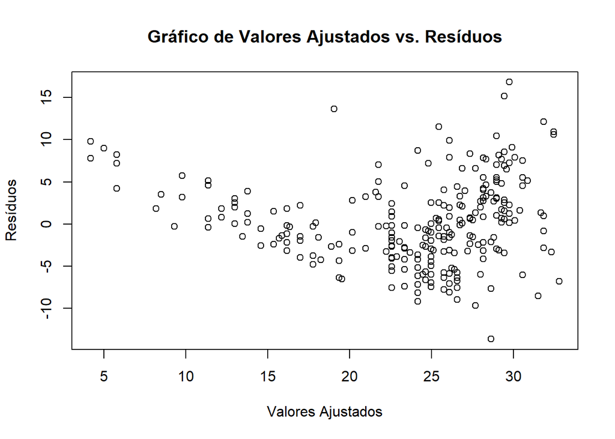

```r
emq_valores_ajustados <- fitted.values(emq_auto)
emq_residuos <- residuals(emq_auto)

plot(emq_valores_ajustados, emq_residuos,
     xlab = "Valores Ajustados",
     ylab = "Resíduos",
     main = "Gráfico de Valores Ajustados vs. Resíduos")
```

calculando EQM de teste:

```r
emq_auto_predict_T <- predict(emq_auto, newdata = T)
```

[output not shown]

## Item 4c

Agora inclua $(\text{horsepower})^2$ no modelo e proceda como no item (b). Qual modelo você escolheria? Justifique.

### Resposta:

```r
emq_auto_quadrado <- glm(formula = mpg ~ horsepower + horsepower^2, data = S)
summary(emq_auto_quadrado)
```

[output not shown]

## Item 4d

Ajuste um modelo de regressão ridge aos dados de $S$, tendo `mpg` com resposta e `displacement`, `horsepower`, `weight` e `acceleration` como preditores, com $\lambda$ escolhido por VC. Obtenha o EQM de teste.

### Resposta:

Transformando dataframe em matriz

```r
X_linha <- S[,3:6]
X_linha_matriz <- as.matrix(X_linha)
Y_linha <- as.matrix(S[,1])
```

```r
# estimando o modelo ridge
emq_auto_ridge <- cv.glmnet(X_linha_matriz, Y_linha, alpha = 0)
# plot(emq_auto_ridge)
coef(emq_auto_ridge, s = "lambda.min")
```

```
## 5 x 1 sparse Matrix of class "dgCMatrix"
##                        s1
## (Intercept)  43.455710885
## displacement -0.017688879
## horsepower   -0.047802163
## weight       -0.003559223
## acceleration -0.062057243
```

```r
lambda_vc <- emq_auto_ridge$lambda.min
```

O lambda escolhido por VC é 0.6505238.

calculando o EQM.

```r
emq_auto_ridge_predict <- predict(emq_auto_ridge, X_linha_matriz, s = "lambda.min")
emq_auto_ridge_eqm <- sqrt(emq_auto_ridge$cvm[emq_auto_ridge$lambda == emq_auto_ridge$lambda.min])
emq_auto_ridge_r2 <- emq_auto_ridge$dev.ratio
```

## Item 4e

Ajuste um modelo de regressão `lasso` e proceda como em (d). Quais coeficientes foram zerados? Comente sobre os resultados obtidos em (d) e (e), baseados no $R^2$ e $EQMI$.

### Resposta

Estimando o modelo de regerssão lasso e imprimindo os coeficientes.

```r
emq_auto_lasso = cv.glmnet(X_linha_matriz, Y_linha, alpha = 1)
coef(emq_auto_lasso, s = "lambda.min")
```

```
## 5 x 1 sparse Matrix of class "dgCMatrix"
##                        s1
## (Intercept)  43.737436088
## displacement -0.011208999
## horsepower   -0.040513292
## weight       -0.004654042
## acceleration  .
```

Como se pode notar, o coeficiente de acceleration foi zerado.

Calculando $R^2$ e $EQMI$ do Lasso.

```r
emq_auto_lasso_eqm <- sqrt(emq_auto_lasso$cvm[emq_auto_lasso$lambda == emq_auto_lasso$lambda.min])
emq_auto_lasso_r2 <- emq_auto_lasso$dev.ratio


emq_auto_lasso_eqm
```

```
## [1] 4.242997
```

```r
emq_auto_lasso_r2
```

[output not shown]